# DATA 624 Homework 5

Both the **Box-Pierce test** and the **Ljung-Box test** were applied to the residuals of the **multiplicative ETS model** for **Takeaway food services in New South Wales** to assess whether they exhibit white noise characteristics. The **Box-Pierce test** produced a **bp_stat of 28.2** with a **p-value of 0.253**, while the **Ljung-Box test** resulted in an **lb_stat of 29.2** with a **p-value of 0.213**. In both cases, the **p-values are well above the common significance threshold (0.05), suggesting that there is no strong evidence of autocorrelation in the residuals**. This indicates that the **multiplicative ETS model adequately captures the underlying patterns in the data**, making it a suitable choice for forecasting. The slightly higher test statistic for the **Ljung-Box test** suggests it may be more sensitive to autocorrelation at higher lags, but the overall conclusion remains the same—**the residuals resemble white noise, and the model is well-fitted**.

**Exercise 8.9**

For the same retail data, try an STL decomposition applied to the Box-Cox transformed series, followed by ETS on the seasonally adjusted data. How does that compare with your best previous forecasts on the test set?

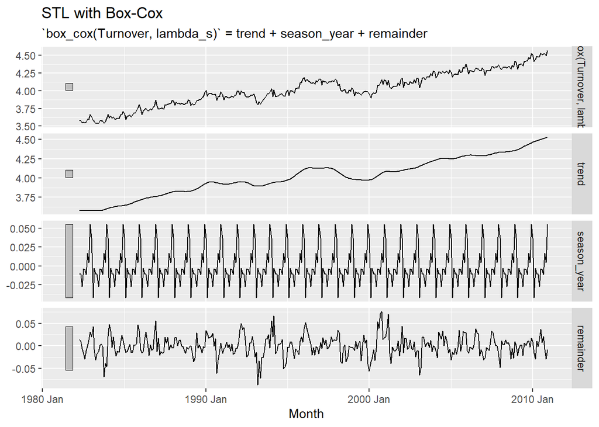

```r
lambda_s <- myseries_train %>%
  features(Turnover, features = guerrero) %>%
  pull(lambda_guerrero)

#stl decomp applied to the box cox transformed data
myseries_train %>%
  model(
    STL(box_cox(Turnover,lambda_s) ~ season(window = "periodic"), robust = TRUE)) %>%
  components() %>%
  autoplot() +
  ggtitle("STL with Box-Cox")
```

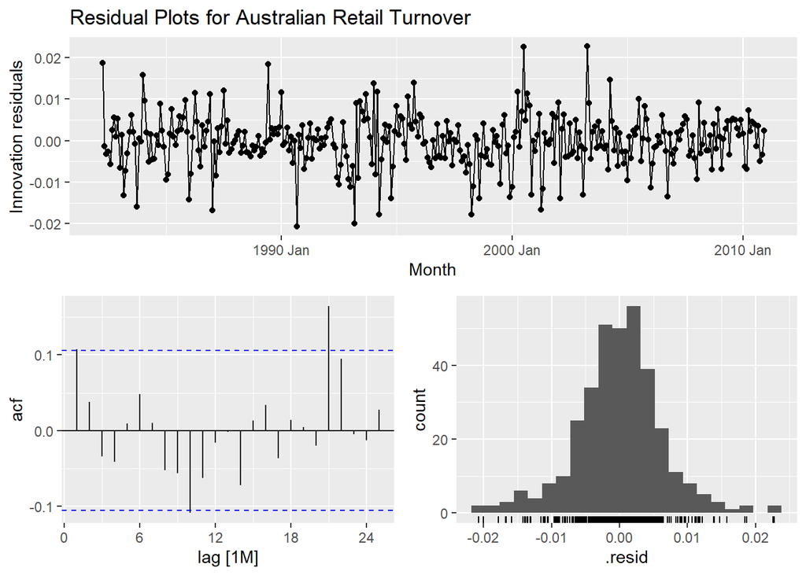

```r
#computed the seasonally adjusted data , stl decomp applied to the box cox transformed data
dcmp <- myseries_train %>%
  model(STL_box = STL(box_cox(Turnover,lambda_s) ~ season(window = "periodic"), robust = TRUE)) %>%
  components()

#replacing turnover with the seasonally adjusted data
myseries_train$Turnover <- dcmp$season_adjust

#modeling on the seasonally adjusted data
fit <- myseries_train %>%
  model(ETS(Turnover ~ error("M") + trend("A") + season("M")))

#checking the residuals
fit %>% gg_tsresiduals()  +
  ggtitle("Residual Plots for Australian Retail Turnover")
```

```r
#produce forecasts for test data
fc <- fit %>%
  forecast(new_data = anti_join(myseries, myseries_train))
fit %>% accuracy() %>%
  select(.model, .type, RMSE)
```

```
## # A tibble: 1 × 3
##   .model                                                        .type      RMSE
##   <chr>                                                         <chr>     <dbl>
## 1 "ETS(Turnover ~ error(\"M\") + trend(\"A\") + season(\"M\"))" Training 0.0254
```

```r
fc %>% accuracy(myseries) %>%
  select(.model, .type, RMSE)
```

```
## # A tibble: 1 × 3
##   .model                                                        .type  RMSE
##   <chr>                                                         <chr> <dbl>
## 1 "ETS(Turnover ~ error(\"M\") + trend(\"A\") + season(\"M\"))" Test   278.
```